# 02_Davis_Shannon_2018

Shannon Davis

September 17, 2018

## 1. R Warmup

### 1a. Create a vector of 100 randomly distributed numbers between 0 and 100 using runif and save the vector into the variable my_vec. If you cannot figure out runif, try ?runif. What information does str and summary tell you about my_vec? How do they differ?

```r
#make a vec wuth 100 random numbers between 0 and 100
my_vec <- runif(n = 100, min = 0, max = 100)

#str and sum my_vec
str(my_vec)
```

```
##  num [1:100] 72.3 90.7 99.7 76.7 67.4 ...
```

```r
summary(my_vec)
```

```
##    Min. 1st Qu.  Median    Mean 3rd Qu.    Max.
##   1.692  27.369  57.159  53.713  82.027  99.663
```

Str tells you the variable class and how many units are in the variable. In this case the class is num that is 100 units long. Str also gives the first few values.

Summary gives a summary of the data in terms of quartiles, min and maz, and the mean.

Both Str and Summary tell you something about the data, but str tells you about the data type and summary tells you about what the data looks like.

### 1b. Try out a little plot. What does hist(my_vec) show you? What information does the helpfile for hist tell you about what you just did?

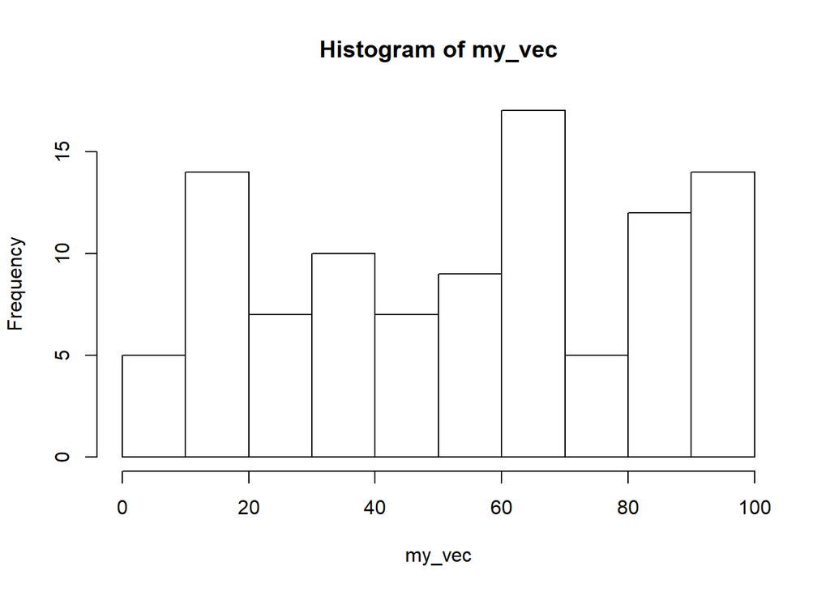

```r
#histogram of my_vec
hist(my_vec)
```

The Hist help file says that R’s default is to create equally spaced “breaks”. Rectangles are used to represent the proportional number of points that fall within the range between breaks from your sample, in this case it is displaying all the frequencies of values in my_vec.

### 1c. Load up the mtcars data set using data(mtcars). Apply the following functions to mtcars: class, str, summary. What do these three functions tell you about mtcars?

```r
#load in data.frame, mtcars
data(mtcars)
#take the class, str and sum mtcars
class(mtcars)
```

```
## [1] "data.frame"
```

```r
str(mtcars)
```

```
## 'data.frame':    32 obs. of  11 variables:
##  $ mpg : num  21 21 22.8 21.4 18.7 18.1 14.3 24.4 22.8 19.2 ...
##  $ cyl : num  6 6 4 6 8 6 8 4 4 6 ...
##  $ disp: num  160 160 108 258 360 ...
##  $ hp  : num  110 110 93 110 175 105 245 62 95 123 ...
##  $ drat: num  3.9 3.9 3.85 3.08 3.15 2.76 3.21 3.69 3.92 3.92 ...
##  $ wt  : num  2.62 2.88 2.32 3.21 3.44 ...
##  $ qsec: num  16.5 17 18.6 19.4 17 ...
##  $ vs  : num  0 0 1 1 0 1 0 1 1 1 ...
##  $ am  : num  1 1 1 0 0 0 0 0 0 0 ...
##  $ gear: num  4 4 4 3 3 3 3 4 4 4 ...
##  $ carb: num  4 4 1 1 2 1 4 2 2 4 ...
```

```r
summary(mtcars)
```

```
##       mpg             cyl             disp             hp
##  Min.   :10.40   Min.   :4.000   Min.   : 71.1   Min.   : 52.0
##  1st Qu.:15.43   1st Qu.:4.000   1st Qu.:120.8   1st Qu.: 96.5
##  Median :19.20   Median :6.000   Median :196.3   Median :123.0
##  Mean   :20.09   Mean   :6.188   Mean   :230.7   Mean   :146.7
##  3rd Qu.:22.80   3rd Qu.:8.000   3rd Qu.:326.0   3rd Qu.:180.0
##  Max.   :33.90   Max.   :8.000   Max.   :472.0   Max.   :335.0
##       drat             wt             qsec             vs
##  Min.   :2.760   Min.   :1.513   Min.   :14.50   Min.   :0.0000
##  1st Qu.:3.080   1st Qu.:2.581   1st Qu.:16.89   1st Qu.:0.0000
##  Median :3.695   Median :3.325   Median :17.71   Median :0.0000
##  Mean   :3.597   Mean   :3.217   Mean   :17.85   Mean   :0.4375
##  3rd Qu.:3.920   3rd Qu.:3.610   3rd Qu.:18.90   3rd Qu.:1.0000
##  Max.   :4.930   Max.   :5.424   Max.   :22.90   Max.   :1.0000
##        am              gear            carb
##  Min.   :0.0000   Min.   :3.000   Min.   :1.000
##  1st Qu.:0.0000   1st Qu.:3.000   1st Qu.:2.000
##  Median :0.0000   Median :4.000   Median :2.000
##  Mean   :0.4062   Mean   :3.688   Mean   :2.812
##  3rd Qu.:1.0000   3rd Qu.:4.000   3rd Qu.:4.000
##  Max.   :1.0000   Max.   :5.000   Max.   :8.000
```

Class tells you the class of the object. In this case data frame.

str tells you how many objects there are and how many varibles there are. In this case there are 32 objects with 11 varibles. It then takes the 11 varibles and tells the data type. In this case all the varible types are num.

summary tells you the quartiles, min and max, and mean of each varible. It breaks the dataframe apart and tells data on each individual varible like mpg, cyl, etc.

### 1d Look at the help file for the class data.frame. What does it tell you about these objects?

The help file says that data.frames are for “tightly coupled collections of variables which share many of the properties of matrices and of lists”. In the case of mtcars we can see cars being compaired by differenct specifications. This is a collection of varibles (cars) that share many properties (mpg, cyl, etc.).

## 2. Sample Properties

### Consider the following vasopressin levels in voles.

```r
vole_vaso <- c(98,96,94,88,86,82,77,74,70,60,
               59,52,50,47,40,35,29,13,6,5)
```

### 2a. Say “Vole vasopressin” 10 times as fast as you can. How many times did you trip up?

11… Which is crazy because I only said it 10 times.

### 2b. What is the mean, median, sd, and interquartile range of the sample?

```r
#find the mean, median, sd and IRQ of vole_vaso
mean(vole_vaso)
```

```
## [1] 58.05
```

```r
median(vole_vaso)
```

```
## [1] 59.5
```

```r
sd(vole_vaso)
```

```
## [1] 29.75244
```

```r
IQR(vole_vaso)
```

```
## [1] 44.25
```

mean = 58.05 median = 59.5 sd = 29.75 IQR = 44.25

### 2c. What is the standard error of the mean (do this with a formula!)?

```r
#find the SE using the formula of vole_vaso
sd(vole_vaso)/sqrt(length(vole_vaso))
```

```
## [1] 6.652849
```

SE = 6.65 ###2d. What does the standard error of the mean tell you about our estimate of the mean values of the population of vole vassopressin?

The standard error tells us how well the sample represents the population. The standard error of vole vassopressin is 6.65 and therefore the probabilty that the population mean is within 6.65 units of the sample mean is 66%.

## 3. Sample Size for upper quartiles.

### We can get the upper quartile value of vole vassopressin with

```r
quantile(vole_vaso, probs = 0.75)
```

```
## 75%
##  83
```

### Let’s assume the sample is representative of the popultion.

### 3a. Use sample() to get just one resample with a sample size of 10. What is its upper quartile?

```r
samp_vole <- sample(vole_vaso, size=10, replace =FALSE)
quantile(samp_vole, probs = 0.75)
```

```
##   75%
## 76.25
```

### 3b. Build an initial data frame for simulations with the sample sizes 5 through 20. Have 100 simulations per sample size.

```r
#make a simulation that have a samp_size of 5-20 and 100 sims per size
sim_vole <- data.frame(samp_size = rep(5:20, 100)) %>%
  mutate(sims = 1:n())
```

### 3c. Use this data frame to get simulated upper quartiles for each sample size.

```r
#use simulation to find upper quartiles
sim_vole <- sim_vole %>%
  rowwise() %>%
  mutate(upperq = quantile(sample(vole_vaso, samp_size, replace=TRUE), probs=0.75)) %>%
  ungroup()
```

### 3d. With a plot, make a guesstimate as to the best sample size for estimating the upper quartile of the population.

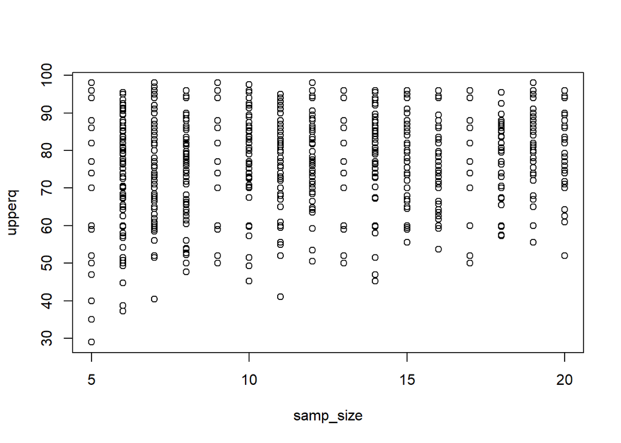

```r
#plot upper quartiles vs sample size
plot(upperq ~ samp_size, data=sim_vole)
```

## 4. SE and CI

### 4a. With the upper quartile simulations, calculate the SD for each sample size using dplyr

```r
#calculate the sd (and se for 4b) for each sample
sim_vole_sum <- sim_vole %>%
  group_by(samp_size) %>%
  summarise(upperq_sd = sd(upperq),
            upperq_se = upperq_sd/sqrt(100)) %>%
  ungroup()

sim_vole_sum
```

```
## # A tibble: 16 x 3
##    samp_size upperq_sd upperq_se
##        <int>     <dbl>     <dbl>
##  1         5     17.1      1.71
##  2         6     13.5      1.35
##  3         7     11.8      1.18
##  4         8     10.8      1.08
##  5         9     11.0      1.10
##  6        10     10.7      1.07
##  7        11     10.1      1.01
##  8        12      9.47     0.947
##  9        13     11.8      1.18
## 10        14     10.5      1.05
## 11        15      9.52     0.952
## 12        16      9.25     0.925
## 13        17      9.41     0.941
## 14        18      8.27     0.827
## 15        19      8.48     0.848
## 16        20      7.84     0.784
```

### 4b. What does this value, the standard error of the upper quartile, mean?

The standard error of the upper quartile tells us how close the upper quartile of the sample is to the upper quartile of the population.

### 4c. What is the CI of the upper quartile with a sample size of 10. What does this mean?

```r
#filter out only samp_size 10
upper_ci <- filter(sim_vole, samp_size == 10)
#find the prob of 95 % and 5 % (95CI)
upper_ci2 <- quantile(sample(upper_ci$upperq, size = 10), probs = c(0, 0.05, 0.95))

upper_ci2
```

```
##     0%     5%    95%
## 59.750 64.700 86.275
```

This tells us what the value for the upper quantile that 95 percent of the time the true value will fall within it.

### 4d. Extra Credit: Instead of having each sim calculate a upper quartile, and then sifting down to the SE of that upper quartile (or the CI), have each simulation calculate a CI. Then, for just a sample size of 10, how many CI’s contain the true value of 83?

```r
#create data frame with sample size of 5-20 and 100 replicates
CI_Q <- data.frame(samp_size = rep(5:20, 100))%>%
  rowwise %>%
  #add 95 CI and 05 CI rows
  mutate(CI_lower = quantile(sample(vole_vaso, samp_size, replace = TRUE), probs = 0.05),
         CI_upper = quantile(sample(vole_vaso, samp_size, replace = TRUE), probs = 0.95))

# get only samp_size = 10

CI_Q_10 <- filter(CI_Q, samp_size == 10)

# get only CI_upper > 83

CI_Q_10_upper <- filter(CI_Q_10, CI_upper > 83)

# get only CI_lower > 83

CI_Q_10_upper_lower <- filter(CI_Q_10_upper, CI_lower < 83)

CI_Q_10_upper_lower
```

```
## Source: local data frame [89 x 3]
## Groups: <by row>
##
## # A tibble: 89 x 3
##    samp_size CI_lower CI_upper
##        <int>    <dbl>    <dbl>
##  1        10    40.4      85.3
##  2        10    20.2      83.2
##  3        10     9.15     95.1
##  4        10     8.6      97.1
##  5        10     5.45     97.1
##  6        10    16.3      96.2
##  7        10     6        87.1
##  8        10    26.7      93.5
##  9        10    22.9      86.1
## 10        10    19.0      87.4
## # ... with 79 more rows
```

```r
# number of samples that 83 falls between the lower and upper CI
nrow(CI_Q_10_upper_lower)
```

```
## [1] 89
```